# Data Science Consulting: Midterm Team Project – Part 1

Jiemin Yu/Jasmine Wang/Katherine Hovde/Sinuo

2020-07-18

## Introduction

```
       Rows Cols
Train 60000   50
Test  10000   50
```

```
     Ankle boot  Bag Coat Dress Pullover Sandal Shirt Sneaker T-shirt/top
[1,]       6000 6000 6000  6000     6000   6000  6000    6000        6000
[2,]       1000 1000 1000  1000     1000   1000  1000    1000        1000
     Trouser
[1,]    6000
[2,]    1000
```

### Model 1

The classification tree is 66% accurate.Rpart has some default parameters that can prevent our tree from growing; such as, minsplit and minbucket.These parameters have been overriden.

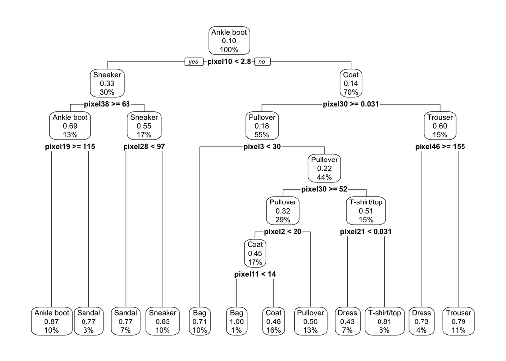

```r
library(rpart)
library(rpart.plot)
rpart3 <- rpart(label~., data = sample.modeldat, method = 'class', minsplit = 2, minbucket = 1)
rpart.plot(rpart3, extra = 108)
```

```r
rpart3.pred= predict(rpart3,test,type="class")
cat("The model is ", 100 * mean(rpart3.pred== test$label), "% accurate.", sep = "")
```

```
The model is 65.92% accurate.
```

```r
res1 = cbind(test$label,rpart3.pred)
tbl1= table(res1[,1], res1[,2])

accuracy1 <- diag(tbl1) / rowSums(tbl1)
print(accuracy1)
```

```
 Ankle boot         Bag        Coat       Dress    Pullover      Sandal
      0.831       0.002       0.040       0.088       0.024       0.000
      Shirt     Sneaker T-shirt/top     Trouser
      0.000       0.721       0.552       0.831
```

### Model 2

**K-means** K-means clustering is an unsupervised learning algorithm which aims to partition n observations into k clusters in which each observation belongs to the cluster with the nearest centroid. The algorithm aims to minimize the squared Euclidean distances between the observation and the centroid of cluster to which it belongs.

Clustering isn’t limited to the consumer information and population sciences, it can be used for imagery analysis as well. KNN algorithm fairs across all parameters of considerations. It is commonly used for its easy of interpretation and low calculation time. In this model, a cluster number of 6 is chosen.

```r
library(class)
testlabel <- test$label
km1.pred = knn(sample.modeldat[,-1],test[,-1],cl = sample.modeldat$label ,k=6)
cat("The model is ", 100 * mean(km1.pred== test$label), "% accurate.", sep = "")
```

```
The model is 79.62% accurate.
```

```r
res2 = cbind(testlabel,km1.pred)
tbl2= table(res2[,1], res2[,2])

vec=c(1:10)
tbl_reorder2 <- tbl2[,match(vec, colnames(tbl2))]
colnames(tbl_reorder2) = c("Ankle boot","Bag","Coat", "Dress","Pullover","Sandal","Shirt","Sneaker","T-shirt/top",  "Trouser")
print(tbl_reorder2)
```

```
              Ankle boot Bag Coat Dress Pullover Sandal Shirt Sneaker
  Ankle boot         938   1    0     0        0     10     0      51
  Bag                  3 926    8     3       26      7    11      11
  Coat                 0   5  692    45      134      0   113       0
  Dress                0   2   45   802       15      0    25       0
  Pullover             0   6  173    10      688      1   104       0
  Sandal              78   6    0     0        0    815     2      99
  Shirt                1  11  103    35      141      0   487       0
  Sneaker             87   0    0     0        0     26     0     887
  T-shirt/top          1  12    5    57       38      1    87       1
  Trouser              0   0    2    26       16      0     6       0

              T-shirt/top Trouser
  Ankle boot            0       0
  Bag                   4       1
  Coat                  3       8
  Dress                38      73
  Pullover             17       1
  Sandal                0       0
  Shirt               214       8
  Sneaker               0       0
  T-shirt/top         784      14
  Trouser               7     943
```

```r
accuracy2 <- diag(tbl_reorder2) / rowSums(tbl_reorder2)
accuracy2 <- sort(accuracy2, decreasing = T)
print(accuracy2)
```

```
    Trouser  Ankle boot         Bag     Sneaker      Sandal       Dress
      0.943       0.938       0.926       0.887       0.815       0.802
T-shirt/top        Coat    Pullover       Shirt
      0.784       0.692       0.688       0.487
```

### Model 3

**K-means** K-means clustering is an unsupervised learning algorithm which aims to partition n observations into k clusters in which each observation belongs to the cluster with the nearest centroid. The algorithm aims to minimize the squared Euclidean distances between the observation and the centroid of cluster to which it belongs.

Clustering isn’t limited to the consumer information and population sciences, it can be used for imagery analysis as well. KNN algorithm fairs across all parameters of considerations. It is commonly used for its easy of interpretation and low calculation time. In this model, a cluster number of 9 is chosen.

```r
testlabel <- test$label
km2.pred = knn(sample.modeldat[,-1],test[,-1],cl = sample.modeldat$label ,k=9)
cat("The model is ", 100 * mean(km2.pred== test$label), "% accurate.", sep = "")
```

```
The model is 79.96% accurate.
```

```r
res3 = cbind(testlabel,km2.pred)
tbl3= table(res3[,1], res3[,2])

tbl_reorder3 <- tbl3[,match(vec, colnames(tbl3))]
colnames(tbl_reorder3) = c("Ankle boot","Bag","Coat", "Dress","Pullover","Sandal","Shirt","Sneaker","T-shirt/top",  "Trouser")
print(tbl_reorder3)
```

```
              Ankle boot Bag Coat Dress Pullover Sandal Shirt Sneaker
  Ankle boot         944   1    0     0        0     11     0      44
  Bag                  3 926    5     4       25      7    13      13
  Coat                 0   5  695    42      135      0   110       0
  Dress                0   2   45   823       18      0    19       0
  Pullover             0   7  157     9      705      1   110       0
  Sandal              77   7    1     2        0    812     2      98
  Shirt                1  12   92    38      157      0   474       0
  Sneaker             90   0    0     0        0     24     0     886
  T-shirt/top          0  14    5    62       41      1    70       1
  Trouser              0   0    1    28       21      0     2       0

              T-shirt/top Trouser
  Ankle boot            0       0
  Bag                   3       1
  Coat                  4       9
  Dress                34      59
  Pullover             10       1
  Sandal                1       0
  Shirt               215      11
  Sneaker               0       0
  T-shirt/top         789      17
  Trouser               6     942
```

```r
accuracy3 <- diag(tbl_reorder3) / rowSums(tbl_reorder3)
accuracy3 <- sort(accuracy3, decreasing = T)
print(accuracy3)
```

```
 Ankle boot     Trouser         Bag     Sneaker       Dress      Sandal
      0.944       0.942       0.926       0.886       0.823       0.812
T-shirt/top    Pullover        Coat       Shirt
      0.789       0.705       0.695       0.474
```

### Model 4

**Random Forest with default parameters**

**Default number of trees: 500 & mtry:7** Random forest models produce flexible, easy to use machine learning algorithm, even without parameter tuning. Starting the first model without parameter tuning as a baseline. Also, because of computational reasons and the running time of the algorithm. For this model, we are using the default number of trees and default mtry.

```r
testlabel <- test$label
rf1 <- randomForest(as.factor(label) ~., data = sample.modeldat, importance = TRUE)


rf1.pred= predict(rf1,test,type="class")

cat("The model is ", 100 * mean(rf1.pred== test$label), "% accurate.", sep = "")
```

```
The model is 82.43% accurate.
```

```r
res4 = cbind(testlabel,rf1.pred)
tbl4= table(res4[,1], res4[,2])

tbl_reorder4 <- tbl4[,match(vec, colnames(tbl4))]
colnames(tbl_reorder4) = c("Ankle boot","Bag","Coat", "Dress","Pullover","Sandal","Shirt","Sneaker","T-shirt/top",  "Trouser")
print(tbl_reorder4)
```

```
              Ankle boot Bag Coat Dress Pullover Sandal Shirt Sneaker
  Ankle boot         910   5    1     0        0     35     0      49
  Bag                  1 954    4     4       15      5    13       2
  Coat                 0   4  781    51       92      0    67       0
  Dress                0   4   27   890       10      1    28       0
  Pullover             0   9  169     8      711      0    95       0
  Sandal              38   5    0     0        0    903     1      53
  Shirt                0  18   94    42      128      0   534       0
  Sneaker             80   0    0     0        0     60     0     860
  T-shirt/top          0  15    5    76       15      2   113       0
  Trouser              0   1    2    29       21      1    10       0

              T-shirt/top Trouser
  Ankle boot            0       0
  Bag                   1       1
  Coat                  1       4
  Dress                18      22
  Pullover              8       0
  Sandal                0       0
  Shirt               182       2
  Sneaker               0       0
  T-shirt/top         769       5
  Trouser               5     931
```

```r
accuracy4 <- diag(tbl_reorder4) / rowSums(tbl_reorder4)
accuracy4 <- sort(accuracy4, decreasing = T)
print(accuracy4)
```

```
        Bag     Trouser  Ankle boot      Sandal       Dress     Sneaker
      0.954       0.931       0.910       0.903       0.890       0.860
       Coat T-shirt/top    Pullover       Shirt
      0.781       0.769       0.711       0.534
```

### Model 5 -

**Random Forest**

Accuracy was used to select the optimal model using the largest number of possible observations while balancing sys time needs. The best value for the model was mtry = 25 with an accuracy of 0.83. Used a smaller train data sample of 5000 rows due to system constraints.

Applied the mtry obtained in Model 5.

Randomforest with mtry = 25 and ntree = 300

```r
#Tuning Random Forest Parameters

metric <- "Accuracy"
control <- trainControl(method="cv", number=10)
set.seed(170)
mtry <- sqrt(ncol(sample.modeldat))


testxy=test$label
rf4 <- randomForest(as.factor(label) ~., data = sample.modeldat, ntree=300, mtry=25, importance = TRUE)
rf4
```

```
Call:
 randomForest(formula = as.factor(label) ~ ., data = sample.modeldat,      ntree = 300, mtry = 25, importance = TRUE)
               Type of random forest: classification
                     Number of trees: 300
No. of variables tried at each split: 25

        OOB estimate of  error rate: 17.28%
Confusion matrix:
            Ankle boot Bag Coat Dress Pullover Sandal Shirt Sneaker T-shirt/top
Ankle boot         457   0    0     0        0     14     1      27           1
Bag                  0 472    4     6        3      4     8       1           2
Coat                 0   7  374    32       43      0    43       0           1
Dress                0   2   23   420        5      0    28       0          13
Pullover             0   8   64     3      377      0    47       0           1
Sandal              15   7    0     0        0    456     0      22           0
Shirt                0   8   51    27       66      0   261       0          85
Sneaker             27   1    0     0        0     32     0     440           0
T-shirt/top          0   3    1    24        2      0    56       0         414
Trouser              0   0    0    22        5      0     5       0           3
            Trouser class.error
Ankle boot        0       0.086
Bag               0       0.056
Coat              0       0.252
Dress             9       0.160
Pullover          0       0.246
Sandal            0       0.088
Shirt             2       0.478
Sneaker           0       0.120
T-shirt/top       0       0.172
Trouser         465       0.070
```

```r
rf4.pred= predict(rf4,test,type="class")


cat("The model is ", 100 * mean(rf4.pred== testxy), "% accurate.", sep = "")
```

```
The model is 82.82% accurate.
```

```r
res5 = cbind(testxy,rf4.pred)
tbl5= table(res5[,1], res5[,2])
tbl_reorder5 <- tbl5[,match(vec, colnames(tbl5))]
colnames(tbl_reorder5) = c("Ankle boot","Bag","Coat", "Dress","Pullover","Sandal","Shirt","Sneaker","T-shirt/top",  "Trouser")
print(tbl_reorder5)
```

```
              Ankle boot Bag Coat Dress Pullover Sandal Shirt Sneaker
  Ankle boot         906   3    0     0        0     34     1      56
  Bag                  1 954    5     2       10      6    18       2
  Coat                 0   5  808    40       84      0    57       0
  Dress                0   4   27   878        9      1    33       0
  Pullover             0   7  176     7      705      0    96       0
  Sandal              37   5    0     0        0    908     1      49
  Shirt                0  19   93    38      110      0   562       0
  Sneaker             80   1    0     0        0     70     0     849
  T-shirt/top          0  16    5    63       10      2   119       0
  Trouser              0   1    2    32       17      1    11       0

              T-shirt/top Trouser
  Ankle boot            0       0
  Bag                   1       1
  Coat                  1       5
  Dress                18      30
  Pullover              9       0
  Sandal                0       0
  Shirt               176       2
  Sneaker               0       0
  T-shirt/top         781       4
  Trouser               5     931
```

```r
accuracy5 <- diag(tbl_reorder5) / rowSums(tbl_reorder5)
accuracy5 <- sort(accuracy5, decreasing = T)
print(accuracy5)
```

```
        Bag     Trouser      Sandal  Ankle boot       Dress     Sneaker
      0.954       0.931       0.908       0.906       0.878       0.849
       Coat T-shirt/top    Pullover       Shirt
      0.808       0.781       0.705       0.562
```

### Model 6

```r
#Divide each pixel value by 255 - this will result in inputs bounded between 0 and 1.
    x= as.matrix(sample.modeldat[,-1]/255)
    y= sample.modeldat$label
    testx=as.matrix(test[,-1]/255)
    testy=test$label
    ridge.mod <- cv.glmnet( x, y, family = "multinomial",type.measure = "class", alpha = 0)

    ridge.pred= predict(ridge.mod,testx,s=ridge.mod$lambda.min,type="class")

cat("The model is ", 100 * mean(ridge.pred== testy), "% accurate.", sep = "")
```

```
The model is 77.74% accurate.
```

```r
res6 = cbind(testy,ridge.pred)
tbl6= table(res6[,1], res6[,2])

print(tbl6)
```

```
              Ankle boot Bag Coat Dress Pullover Sandal Shirt Sneaker
  Ankle boot         909   0    0     0        0     36     0      54
  Bag                  6 916    5    17       10     15    13      14
  Coat                 0   3  720    57      123      6    66       0
  Dress                0   2   18   857       13      4    23       0
  Pullover             0  15  183    11      633     14   128       0
  Sandal              45   9    1     0        0    859     0      83
  Shirt                1  24  164    58      127     25   367       0
  Sneaker             84   0    0     0        0     85     0     831
  T-shirt/top          1  31    4    96       13     11    45       1
  Trouser              0   0    3    54       22      3     5       0

              T-shirt/top Trouser
  Ankle boot            1       0
  Bag                   3       1
  Coat                  2      23
  Dress                39      44
  Pullover             12       4
  Sandal                3       0
  Shirt               212      22
  Sneaker               0       0
  T-shirt/top         773      25
  Trouser               4     909
```

```r
accuracy6 <- diag(tbl6) / rowSums(tbl6)
accuracy6 <- sort(accuracy6, decreasing = T)
print(accuracy6)
```

```
        Bag  Ankle boot     Trouser      Sandal       Dress     Sneaker
      0.916       0.909       0.909       0.859       0.857       0.831
T-shirt/top        Coat    Pullover       Shirt
      0.773       0.720       0.633       0.367
```

As expected the model was best at identifying items with a unique shape such as bags, trousers and ankle boots but rather poor at identifying objects with generic shape such as shirts, pullovers and coats.

### Model 7

**LASSO Regression**  
Similar to the Ridge regression, LASSO Regularization is another commonly used penalized regression technique. The method overcomes the disadvantage of Ridge regression by not only punishing high values of the coefficients but actually setting them to zero if they are not relevant. Therefore, it also perform a feature selection process for the model, because it constraints the value of the estimated coefficients by setting some of them to zero, which helps interpretability of the final model. The lambda parameter control the amount of regularization, the best tuning parameter is learnt through 5-fold cross validation method, which balances underfitting and overfitting.

```r
#Divide each pixel value by 255 - this will result in inputs bounded between 0 and 1.
x= as.matrix(sample.modeldat[,-1]/255)
y= sample.modeldat$label
testx=as.matrix(test[,-1]/255)
testy=test$label
lasso.mod <- cv.glmnet( x, y, family = "multinomial",type.measure = "class", alpha = 1, nfolds = 5)

myCoefs <- coef(lasso.mod, s="lambda.min");
myCoefs[1]
```

```
$`Ankle boot`
50 x 1 sparse Matrix of class "dgCMatrix"
                      1
(Intercept) -2.27532865
pixel1      -3.69422232
pixel2       .
pixel3       .
pixel4       .
pixel5       .
pixel6       4.43144543
pixel7      11.80346378
pixel8       .
pixel9       .
pixel10      .
pixel11      .
pixel12      .
pixel13      .
pixel14      7.87568022
pixel15     -2.73599598
pixel16      .
pixel17     -5.66633979
pixel18      0.14476171
pixel19      2.42428297
pixel20      2.71578000
pixel21      0.92600486
pixel22      .
pixel23     -7.98952494
pixel24     -5.25095425
pixel25      3.10256122
pixel26      2.65519359
pixel27      1.09524125
pixel28      2.81097301
pixel29      8.98585672
pixel30     -0.88216075
pixel31      .
pixel32      0.05422141
pixel33      .
pixel34      .
pixel35      0.67765432
pixel36      1.43771640
pixel37     -3.81786198
pixel38      .
pixel39      .
pixel40     -3.40272206
pixel41      1.15828189
pixel42      2.18763564
pixel43      .
pixel44      .
pixel45      .
pixel46      .
pixel47      .
pixel48      .
pixel49      .
```

```r
lasso.pred= predict(lasso.mod,testx,s=lasso.mod$lambda.min,type="class")

cat("The model is ", 100 * mean(lasso.pred== testy), "% accurate.", sep = "")
```

```
The model is 80.48% accurate.
```

```r
res7 = cbind(testy,lasso.pred)
tbl7= table(res7[,1], res7[,2])

print(tbl7)
```

```
              Ankle boot Bag Coat Dress Pullover Sandal Shirt Sneaker
  Ankle boot         935   1    0     0        0     26     0      38
  Bag                  4 932    5     8        7     16    18       5
  Coat                 0   2  760    41      106      0    84       0
  Dress                0   2   23   847       15      0    26       0
  Pullover             0  11  176    11      654      0   128       0
  Sandal              28   8    0     0        0    900     0      62
  Shirt                1  21  138    55      131      2   436       0
  Sneaker             65   0    0     0        0     50     0     885
  T-shirt/top          2  34    2    70       17      4    74       2
  Trouser              0   0    2    46       14      2     5       0

              T-shirt/top Trouser
  Ankle boot            0       0
  Bag                   2       3
  Coat                  0       7
  Dress                46      41
  Pullover             16       4
  Sandal                2       0
  Shirt               202      14
  Sneaker               0       0
  T-shirt/top         774      21
  Trouser               6     925
```

```r
accuracy7 <- diag(tbl7) / rowSums(tbl7)
accuracy7 <- sort(accuracy7, decreasing = T)
print(accuracy7)
```

```
 Ankle boot         Bag     Trouser      Sandal     Sneaker       Dress
      0.935       0.932       0.925       0.900       0.885       0.847
T-shirt/top        Coat    Pullover       Shirt
      0.774       0.760       0.654       0.436
```

We print out the coefficients from the lasso model, clearly some of the estimated coefficients has been set to zero. LASSO was also best at identifying items with a unique shape such as bags, trousers and ankle boots but rather poor at identifying objects with generic shape such as shirts, pullovers and coats.

### Model 8

**SVM classification algorithm**

Support Vector Machines (SVM) is a supervised learning method and can be used for regression and classification problems. The ‘e1071’ package provides ‘svm’. Given a classification problem, the best possible predictive performance is better for a nonlinear kernel, in particular, we used the Radial Basis kernel here.  
In this method, we use the caret’s train() function and define the ‘svmRadial’ method in a method. Cost parameter trades off mis_classification of training examples against simplicity of the decision surface. Low value C tends to make decision surface smooth, while a high C tries all training examples correctly. After 5-fold cross-validation, we define the best C value for SVM then train all 9 models based on that.

```r
x= as.matrix(sample.modeldat[,-1])
y= sample.modeldat$label
testx=as.matrix(test[,-1])
testy=test$label

library(e1071) #SVM
library(caret) #select tuning parameters

svm_mdl <- train(factor(label)~.,data=sample.modeldat,
                 method="svmRadial",
                 trControl=trainControl(method="cv", number=5),
                 tuneGrid=data.frame(sigma = 0.01, C =c(1,3,5,10)))
print(svm_mdl)
```

```
Support Vector Machines with Radial Basis Function Kernel

5000 samples
  49 predictor
  10 classes: 'Ankle boot', 'Bag', 'Coat', 'Dress', 'Pullover', 'Sandal', 'Shirt', 'Sneaker', 'T-shirt/top', 'Trouser'

No pre-processing
Resampling: Cross-Validated (5 fold)
Summary of sample sizes: 4000, 4000, 4000, 4000, 4000
Resampling results across tuning parameters:

  C   Accuracy  Kappa
   1  0.8048    0.7831111
   3  0.8198    0.7997778
   5  0.8316    0.8128889
  10  0.8404    0.8226667

Tuning parameter 'sigma' was held constant at a value of 0.01
Accuracy was used to select the optimal model using the largest value.
The final values used for the model were sigma = 0.01 and C = 10.
```

```r
# Radial kernel has the best performance When Cost equals to 10.
    svm.pred = predict(svm_mdl,newdata=testx)

cat("The model is ", 100 * mean(svm.pred== testy), "% accurate.", sep = "")
```

```
The model is 84.33% accurate.
```

```r
res8 = cbind(testy,svm.pred)
tbl8= table(res8[,1], res8[,2])

tbl_reorder8 <- tbl8[,match(vec, colnames(tbl8))]

print(tbl_reorder8)
```

```
                1   2   3   4   5   6   7   8   9  10
  Ankle boot  937   0   0   0   0  19   0  44   0   0
  Bag           3 959   5   3   6   5   9   4   4   2
  Coat          0   2 814  37  72   0  74   0   0   1
  Dress         0   3  31 875  12   0  19   0  31  29
  Pullover      0   4 144  13 740   0  81   0  17   1
  Sandal       23   5   0   0   0 916   1  55   0   0
  Shirt         1  12  90  56 126   0 526   0 184   5
  Sneaker      54   0   0   0   0  30   0 916   0   0
  T-shirt/top   1  16   2  62  17   4  94   0 793  11
  Trouser       0   0   1  26   6   1   4   0   5 957
```

```r
accuracy8 <- diag(tbl_reorder8) / rowSums(tbl_reorder8)

accuracy8 <- sort(accuracy8, decreasing = T)
print(accuracy8)
```

```
        Bag     Trouser  Ankle boot      Sandal     Sneaker       Dress
      0.959       0.957       0.937       0.916       0.916       0.875
       Coat T-shirt/top    Pullover       Shirt
      0.814       0.793       0.740       0.526
```

Comparing to the previous two model(Ridge/Lasso), SVM was better at identifying objects with generic shape such as shirts, pullovers and coats.

### Model 9

GBM is unique compared to other decision tree algorithms because it builds models sequentially with higher weights given to those cases that were poorly predicted in previous models, thus improving accuracy incrementally instead of simply taking an average of all models like a random forest algorithm would. In this model, gmb function from gbm package is used. n.trees is set to be 200.

```r
library(gbm)
model_gbm1=gbm(label~.,data=sample.modeldat,shrinkage=0.01,distribution = 'multinomial',cv.folds = 5,n.trees = 200,n.minobsinnode = 10)

pred_gbm1=predict(model_gbm1,newdata=test,n.trees = 200,type = "response")
result_gbm1=colnames(pred_gbm1)[apply(pred_gbm1,1,which.max)]

cat("The model is ", 100 * mean(result_gbm1 ==test$label), "% accurate.", sep = "")
```

```
The model is 69.95% accurate.
```

### Model 10

GBM is unique compared to other decision tree algorithms because it builds models sequentially with higher weights given to those cases that were poorly predicted in previous models, thus improving accuracy incrementally instead of simply taking an average of all models like a random forest algorithm would. In this model, gmb function from gbm package is used. n.trees is set to be 500.

```r
library(gbm)
model_gbm2=gbm(label~.,data=sample.modeldat,shrinkage=0.01,distribution = 'multinomial',cv.folds = 5,n.trees = 500,n.minobsinnode = 10)

pred_gbm2=predict(model_gbm2,newdata=test,n.trees = 500,type = "response")
result_gbm2=colnames(pred_gbm2)[apply(pred_gbm2,1,which.max)]

cat("The model is ", 100 * mean(result_gbm2 ==test$label), "% accurate.", sep = "")
```

```
The model is 75.61% accurate.
```

## Scoreboard

The preiminary result will be presented below.

|  | ModelType | samplesize | Traindata | A | B | C | Points |
| --- | --- | --- | --- | --- | --- | --- | --- |
| 1 | class.tree | 1000 | dat_1000_1 | 0.0167 | 0.003 | 0.3473 | 0.2633 |
| 2 | class.tree | 1000 | dat_1000_2 | 0.0167 | 0.0026 | 0.3473 | 0.2632 |
| 3 | class.tree | 1000 | dat_1000_3 | 0.0167 | 0.0032 | 0.3473 | 0.2633 |
| 4 | class.tree | 5000 | dat_5000_1 | 0.0833 | 0.0142 | 0.3408 | 0.2695 |
| 5 | class.tree | 5000 | dat_5000_2 | 0.0833 | 0.0134 | 0.3408 | 0.2694 |
| 6 | class.tree | 5000 | dat_5000_3 | 0.0833 | 0.0135 | 0.3408 | 0.2695 |
| 7 | class.tree | 20000 | dat_20000_1 | 0.3333 | 0.0449 | 0.353 | 0.3192 |
| 8 | class.tree | 20000 | dat_20000_2 | 0.3333 | 0.0454 | 0.353 | 0.3193 |
| 9 | class.tree | 20000 | dat_20000_3 | 0.3333 | 0.0452 | 0.353 | 0.3193 |
| 10 | KNN-6 | 1000 | dat_1000_1 | 0.0167 | 0.0072 | 0.2495 | 0.1903 |

[output cut: 80 more lines]

The scoreboard will be presented below.

|  | ModelType | samplesize | a | b | c | points |
| --- | --- | --- | --- | --- | --- | --- |
| 1 | SVM | 5000 | 0.0833 | 0.1866 | 0.1567 | 0.1487 |
| 2 | rf | 5000 | 0.0833 | 0.0866 | 0.176 | 0.1532 |
| 3 | SVM | 1000 | 0.0167 | 0.0342 | 0.2009 | 0.1566 |
| 4 | rf1 | 5000 | 0.0833 | 0.1452 | 0.1742 | 0.1576 |
| 5 | rf | 1000 | 0.0167 | 0.0134 | 0.2168 | 0.1665 |
| 6 | KNN-9 | 5000 | 0.0833 | 0.0358 | 0.2012 | 0.167 |
| 7 | KNN-6 | 5000 | 0.0833 | 0.0343 | 0.2033 | 0.1684 |
| 8 | rf1 | 1000 | 0.0167 | 0.0227 | 0.2183 | 0.1685 |
| 9 | ridge | 1000 | 0.0167 | 0.0743 | 0.2279 | 0.1809 |
| 10 | KNN-9 | 1000 | 0.0167 | 0.0078 | 0.2493 | 0.1903 |

[output cut: 20 more lines]

## Discussion

Model scope covers Traditional methods: simple classification tree, Regression method with penalization: ridge / lasso, non-parametric method : K-means/SVM(Radial kernal) and Ensemble method : Random forest and GBM.

Simple Classification tree give less than 70% accuracy rate ,thus are not powerful for this type of classification problem. Traditional classification regression with penalization (Ridge/Lasso) give out accuracy rate around 80%, Lasso methodology has performed feature selection and provide slightly better results than Ridge regression, however request longer computation time.

Non-parameteric KNN methodology give out accuracy rate around 80%, and overall quick computation speed. SVM methodology give out best accuracy rate among the all models, however request longer time for model fitting.

Random forests and GBM are an ensemble learning method for classification, there are higher requirement on system to perform parameter tuning process and usually should use a smaller train data sample to do the fitting.

Overall, model were best at identifying items with a unique shape such as bags, trousers and ankle boots but rather poor at identifying objects with generic shape such as shirts, pullovers and coats.

Also, different models have different strength. We compared the overall points, misclassification rate and time across different models.

```
[1] "Points comparision by models/Samplesize"
```

```
             1000   5000  20000
class.tree 0.2633 0.2695 0.3193
GBM-1      0.2560 0.2733 0.3842
GBM-2      0.2606 0.3034 0.3847
KNN-6      0.1908 0.1684 0.2081
KNN-9      0.1903 0.1670 0.2042
lasso      0.2383 0.2569 0.2885
rf         0.1665 0.1532 0.2084
rf1        0.1685 0.1576 0.2409
ridge      0.1809 0.2155 0.3157
SVM        0.1566 0.1487 0.2541
```

```
[1] "Misclassification comparision by models/Samplesize"
```

```
             1000   5000  20000
class.tree 0.3473 0.3408 0.3530
GBM-1      0.3142 0.3025 0.3123
GBM-2      0.3117 0.3013 0.3130
KNN-6      0.2502 0.2033 0.1741
KNN-9      0.2493 0.2012 0.1721
lasso      0.2252 0.1925 0.1846
rf         0.2168 0.1760 0.1477
rf1        0.2183 0.1742 0.1469
ridge      0.2279 0.2226 0.2210
SVM        0.2009 0.1567 0.1388
```

```
[1] "Time comparision by models/Samplesize"
```

```
             1000   5000  20000
class.tree 0.0029 0.0137 0.0452
GBM-1      0.1782 0.3391 1.0000
GBM-2      0.2429 0.6492 1.0000
KNN-6      0.0073 0.0343 0.2756
KNN-9      0.0078 0.0358 0.2512
lasso      0.6691 1.0000 1.0000
rf         0.0134 0.0866 0.4757
rf1        0.0227 0.1452 0.8064
ridge      0.0743 0.3604 1.0000
SVM        0.0342 0.1866 1.0000
```

## Model Development Responsibilities

For the 10 models, please list the names of the developers along with percentages for how the responsibilities were divided.

1. Katherine - Classification Tree
2. Jasmine - K-Nearest Neighbors n=6
3. Jasmine - K-Nearest Neighbors n=9
4. Katherine - Random Forest without tuning
5. Katherine - Random Forest with tuning
6. Jiemin Yu - Ridge
7. Jiemin Yu - Lasso
8. Jiemin Yu - SVM
9. Sinuo - gbm1 10.Sinuo - gbm2

Part1 consolidate: Jasmine, Jiemin Part2-4 consolidate: Jiemin, Katherine

Function writing: Jiemin Sampling: Jiemin, Jasmine

## References

https://cran.r-project.org/web/packages/glmnet/glmnet.pdf

https://en.wikipedia.org/wiki/Lasso_(statistics)

https://appsilon.com/zalandos-images-classification-using-h2o-with-r/